# Actividad - Proyecto práctico

```python
history_p2 = dqn_p2.fit(
    env_p2,
    callbacks=callbacks_p2,
    nb_steps=80000,
    log_interval=1000,
    visualize=False
)
```

```
Training for 80000 steps ...
Interval 1 (0 steps performed)
```

```
2 episodes - episode_reward: -500.000 [-500.000, -500.000]

Interval 2 (1000 steps performed)
2 episodes - episode_reward: -500.000 [-500.000, -500.000] - loss: 1.258 - mae: 28.055 - mean_q: -41.176 - mean_eps: 0.976

Interval 3 (2000 steps performed)
2 episodes - episode_reward: -500.000 [-500.000, -500.000] - loss: 0.906 - mae: 26.643 - mean_q: -38.933 - mean_eps: 0.960

Interval 4 (3000 steps performed)
2 episodes - episode_reward: -500.000 [-500.000, -500.000] - loss: 0.941 - mae: 25.715 - mean_q: -37.474 - mean_eps: 0.945

Interval 5 (4000 steps performed)
2 episodes - episode_reward: -500.000 [-500.000, -500.000] - loss: 1.008 - mae: 24.566 - mean_q: -35.659 - mean_eps: 0.929

Interval 6 (5000 steps performed)
2 episodes - episode_reward: -438.500 [-500.000, -377.000] - loss: 0.886 - mae: 22.384 - mean_q: -32.285 - mean_eps: 0.913

Interval 7 (6000 steps performed)
2 episodes - episode_reward: -463.500 [-500.000, -427.000] - loss: 0.609 - mae: 20.847 - mean_q: -29.960 - mean_eps: 0.897

Interval 8 (7000 steps performed)
2 episodes - episode_reward: -436.000 [-500.000, -372.000] - loss: 0.685 - mae: 19.028 - mean_q: -27.207 - mean_eps: 0.881

Interval 9 (8000 steps performed)
3 episodes - episode_reward: -353.667 [-500.000, -259.000] - loss: 0.485 - mae: 17.422 - mean_q: -24.980 - mean_eps: 0.865

Interval 10 (9000 steps performed)
3 episodes - episode_reward: -385.667 [-500.000, -314.000] - loss: 0.419 - mae: 16.714 - mean_q: -24.056 - mean_eps: 0.850

Interval 11 (10000 steps performed)
2 episodes - episode_reward: -324.500 [-346.000, -303.000] - loss: 0.483 - mae: 16.654 - mean_q: -24.076 - mean_eps: 0.834

Interval 12 (11000 steps performed)
3 episodes - episode_reward: -454.667 [-500.000, -416.000] - loss: 0.459 - mae: 17.110 - mean_q: -24.841 - mean_eps: 0.818

Interval 13 (12000 steps performed)
2 episodes - episode_reward: -379.000 [-436.000, -322.000] - loss: 0.483 - mae: 17.945 - mean_q: -26.139 - mean_eps: 0.802

Interval 14 (13000 steps performed)
3 episodes - episode_reward: -317.000 [-386.000, -262.000] - loss: 0.541 - mae: 19.119 - mean_q: -27.924 - mean_eps: 0.786
```

[output cut: 183 more lines]

```

Interval 76 (75000 steps performed)
14 episodes - episode_reward: -76.357 [-99.000, -62.000] - loss: 0.612 - mae: 19.842 - mean_q: -28.466 - mean_eps: 0.050

Interval 77 (76000 steps performed)
13 episodes - episode_reward: -76.462 [-91.000, -62.000] - loss: 0.599 - mae: 19.866 - mean_q: -28.525 - mean_eps: 0.050

Interval 78 (77000 steps performed)
12 episodes - episode_reward: -81.167 [-106.000, -63.000] - loss: 0.609 - mae: 19.796 - mean_q: -28.392 - mean_eps: 0.050

Interval 79 (78000 steps performed)
12 episodes - episode_reward: -81.667 [-111.000, -61.000] - loss: 0.582 - mae: 19.907 - mean_q: -28.540 - mean_eps: 0.050

Interval 80 (79000 steps performed)
done, took 582.886 seconds
```

```python
dqn_p2.save_weights(weights_filename_p2, overwrite=True)

print("Pesos finales guardados en:")
print(weights_filename_p2)

print("Pesos best:")
print(best_weights_path_p2)
```

```
Pesos finales guardados en:
C:\Users\kevin\Downloads\ESTUDIO MASTER EN IA\Aprendizaje por refuerzo\PROYECTO\Proyecto RL\dqn_Acrobot-v1_p2_weights.h5f
Pesos best:
C:\Users\kevin\Downloads\ESTUDIO MASTER EN IA\Aprendizaje por refuerzo\PROYECTO\Proyecto RL\dqn_Acrobot-v1_p2_best.h5f
```

```python
# Evaluación de la propuesta p2 usando los mejores pesos guardados

dqn_p2.load_weights(best_weights_path_p2)
dqn_p2.test_policy = EpsGreedyQPolicy(eps=0.0)

env_test_p2 = gym.make(env_name)

history_test_p2 = dqn_p2.test(
    env_test_p2,
    nb_episodes=100,
    visualize=False,
    verbose=1
)

env_test_p2.close()

test_rewards_p2 = history_test_p2.history['episode_reward']

print("MEDIA TEST PROPUESTA P2:", np.mean(test_rewards_p2))
print("MEJOR EPISODIO:", np.max(test_rewards_p2))
print("PEOR EPISODIO:", np.min(test_rewards_p2))
print("DESVIACIÓN ESTÁNDAR:", np.std(test_rewards_p2))
```

```
Testing for 100 episodes ...
Episode 1: reward: -71.000, steps: 72
Episode 2: reward: -70.000, steps: 71
Episode 3: reward: -77.000, steps: 78
Episode 4: reward: -78.000, steps: 79
Episode 5: reward: -74.000, steps: 75
Episode 6: reward: -93.000, steps: 94
Episode 7: reward: -100.000, steps: 101
Episode 8: reward: -76.000, steps: 77
Episode 9: reward: -69.000, steps: 70
Episode 10: reward: -84.000, steps: 85
Episode 11: reward: -69.000, steps: 70
Episode 12: reward: -70.000, steps: 71
Episode 13: reward: -104.000, steps: 105
Episode 14: reward: -77.000, steps: 78
Episode 15: reward: -69.000, steps: 70
Episode 16: reward: -61.000, steps: 62
Episode 17: reward: -96.000, steps: 97
Episode 18: reward: -84.000, steps: 85
Episode 19: reward: -70.000, steps: 71
Episode 20: reward: -77.000, steps: 78
Episode 21: reward: -69.000, steps: 70
Episode 22: reward: -70.000, steps: 71
Episode 23: reward: -70.000, steps: 71
Episode 24: reward: -62.000, steps: 63
Episode 25: reward: -61.000, steps: 62
Episode 26: reward: -69.000, steps: 70
Episode 27: reward: -91.000, steps: 92
Episode 28: reward: -84.000, steps: 85
Episode 29: reward: -89.000, steps: 90
Episode 30: reward: -75.000, steps: 76
Episode 31: reward: -70.000, steps: 71
Episode 32: reward: -69.000, steps: 70
Episode 33: reward: -61.000, steps: 62
Episode 34: reward: -86.000, steps: 87
Episode 35: reward: -62.000, steps: 63
Episode 36: reward: -69.000, steps: 70
Episode 37: reward: -77.000, steps: 78
Episode 38: reward: -100.000, steps: 101
Episode 39: reward: -84.000, steps: 85
```

[output cut: 50 more lines]

```
Episode 90: reward: -75.000, steps: 76
Episode 91: reward: -69.000, steps: 70
Episode 92: reward: -62.000, steps: 63
Episode 93: reward: -62.000, steps: 63
Episode 94: reward: -69.000, steps: 70
Episode 95: reward: -69.000, steps: 70
Episode 96: reward: -62.000, steps: 63
Episode 97: reward: -61.000, steps: 62
Episode 98: reward: -70.000, steps: 71
Episode 99: reward: -77.000, steps: 78
Episode 100: reward: -84.000, steps: 85
MEDIA TEST PROPUESTA P2: -75.32
MEJOR EPISODIO: -61.0
PEOR EPISODIO: -105.0
DESVIACIÓN ESTÁNDAR: 11.454152085597606
```

```python
with open(log_filename_p2, 'r') as f:
    log_p2 = json.load(f)

episode_reward_p2 = log_p2['episode_reward']
nb_episode_steps_p2 = log_p2['nb_episode_steps']
nb_steps_p2 = log_p2['nb_steps']

print("Episodios registrados:", len(episode_reward_p2))
print("Último paso registrado:", nb_steps_p2[-1])
print("Recompensa media entrenamiento:", np.mean(episode_reward_p2))
print("Mejor recompensa entrenamiento:", np.max(episode_reward_p2))
print("Peor recompensa entrenamiento:", np.min(episode_reward_p2))
```

```
Episodios registrados: 630
Último paso registrado: 79962
Recompensa media entrenamiento: -125.95555555555555
Mejor recompensa entrenamiento: -60.0
Peor recompensa entrenamiento: -500.0
```

```python
video_folder_p2 = os.path.join(drive_root, "videos_proyecto_p2")

env_video_p2 = gym.make(env_name)

env_video_p2 = Monitor(
    env_video_p2,
    video_folder_p2,
    force=True,
    video_callable=lambda episode_id: True
)

dqn_p2.load_weights(best_weights_path_p2)
dqn_p2.test_policy = EpsGreedyQPolicy(eps=0.0)

print("Grabando vídeo de la propuesta p2...")

dqn_p2.test(
    env_video_p2,
    nb_episodes=3,
    visualize=False,
    verbose=1
)

env_video_p2.close()

print("Vídeo guardado en:", video_folder_p2)
```

```
Grabando vídeo de la propuesta p2...
Testing for 3 episodes ...
Episode 1: reward: -96.000, steps: 97
Episode 2: reward: -75.000, steps: 76
Episode 3: reward: -71.000, steps: 72
Vídeo guardado en: C:\Users\kevin\Downloads\ESTUDIO MASTER EN IA\Aprendizaje por refuerzo\PROYECTO\Proyecto RL\videos_proyecto_p2
```

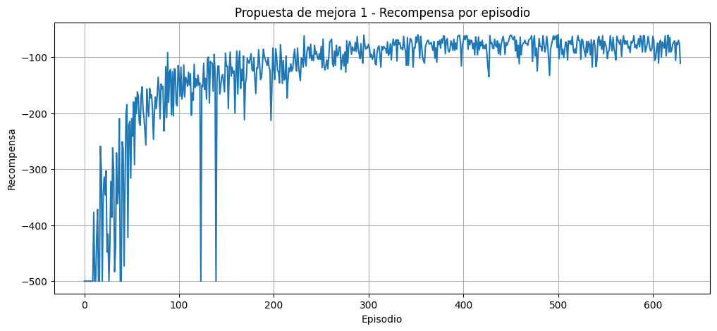

```python
plt.figure(figsize=(12, 5))
plt.plot(episode_reward_p2)
plt.title('Propuesta de mejora 1 - Recompensa por episodio')
plt.xlabel('Episodio')
plt.ylabel('Recompensa')
plt.grid(True)
plt.show()
```

Se observa una clara fase de aprendizaje al inicio del entrenamiento: los primeros episodios registran recompensas cercanas al mínimo (-500), coincidiendo con el periodo de alta exploración. A medida que avanzan los episodios, la recompensa mejora de forma progresiva hasta estabilizarse en un rango mucho más favorable, aproximadamente entre -60 y -150, que se mantiene de forma sostenida durante la mayor parte del entrenamiento. Esto indica que el agente no solo mejora, sino que consolida un comportamiento eficiente y lo mantiene de forma consistente.

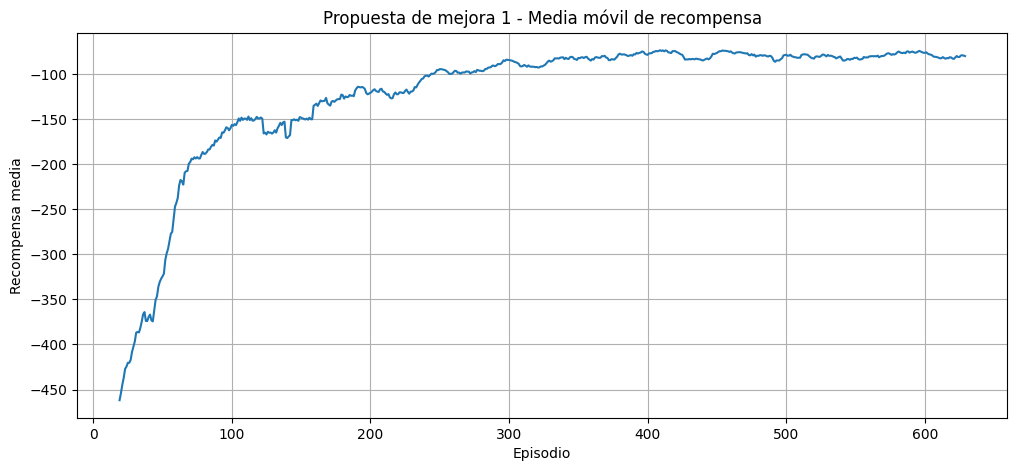

```python
window = 20

moving_avg_p2 = np.convolve(
    episode_reward_p2,
    np.ones(window) / window,
    mode='valid'
)

plt.figure(figsize=(12, 5))
plt.plot(range(window - 1, len(episode_reward_p2)), moving_avg_p2)
plt.title('Propuesta de mejora 1 - Media móvil de recompensa')
plt.xlabel('Episodio')
plt.ylabel('Recompensa media')
plt.grid(True)
plt.show()
```

La media móvil confirma esta lectura de forma aún más clara: muestra una curva de aprendizaje bien definida, con una subida marcada durante la primera parte del entrenamiento y una posterior estabilización en valores cercanos a -100, sin retrocesos significativos hacia el final. Esta forma de "curva de aprendizaje" es la señal característica de una política que converge de manera efectiva hacia un comportamiento óptimo.

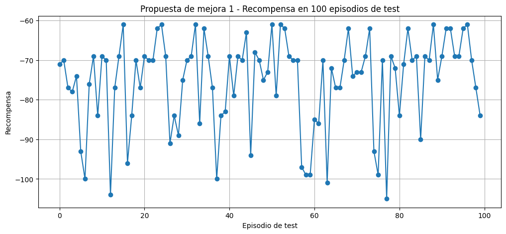

```python
plt.figure(figsize=(12, 5))
plt.plot(test_rewards_p2, marker='o')
plt.title('Propuesta de mejora 1 - Recompensa en 100 episodios de test')
plt.xlabel('Episodio de test')
plt.ylabel('Recompensa')
plt.grid(True)
plt.show()
```

Los resultados de evaluación refuerzan la solidez del entrenamiento: con una media de -75.32, un mejor episodio de -61 y un peor de apenas -105, la política se comporta de manera consistente y sin fallos, resolviendo el entorno en cada uno de los 100 episodios evaluados. La baja desviación estándar (11.45) confirma que el desempeño no depende del azar, sino que refleja un comportamiento aprendido de forma estable y repetible.

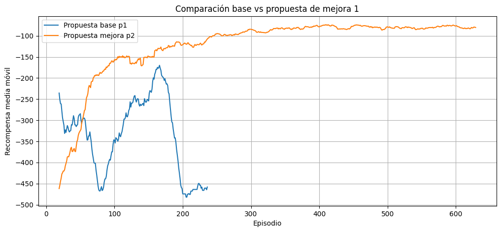

```python
base_log_path = os.path.join(drive_root, f'dqn_{env_name}_p1_log.json')
p2_log_path = log_filename_p2

with open(base_log_path, 'r') as f:
    log_base = json.load(f)

with open(p2_log_path, 'r') as f:
    log_p2 = json.load(f)

rewards_base = log_base['episode_reward']
rewards_p2 = log_p2['episode_reward']

window = 20

media_base = np.convolve(
    rewards_base,
    np.ones(window) / window,
    mode='valid'
)

media_p2 = np.convolve(
    rewards_p2,
    np.ones(window) / window,
    mode='valid'
)

plt.figure(figsize=(12, 5))
plt.plot(range(window - 1, len(rewards_base)), media_base, label='Propuesta base p1')
plt.plot(range(window - 1, len(rewards_p2)), media_p2, label='Propuesta mejora p2')
plt.title('Comparación base vs propuesta de mejora 1')
plt.xlabel('Episodio')
plt.ylabel('Recompensa media móvil')
plt.legend()
plt.grid(True)
plt.show()
```

Esta diferencia se traslada de forma directa a los resultados de test: mientras que la propuesta base logra una media de -143.83, con episodios que todavía caen ocasionalmente en el fallo total (-500), la propuesta de mejora 1 obtiene una media de -75.32, con una desviación estándar baja (11.45) y sin ningún episodio fallido. Es decir, la mejora no se limita a un mejor promedio, sino que se traduce en una política más consistente y fiable, capaz de repetir un comportamiento cercano al óptimo en prácticamente cualquier episodio.

## 4.1 Conclusión.

Los resultados obtenidos confirman que la exploración progresiva con epsilon decreciente constituye una mejora sustancial frente a la propuesta base. Al permitir que el agente explore de forma extensa en las primeras etapas del entrenamiento y reduzca gradualmente la aleatoriedad, la propuesta de mejora 1 logra descubrir y consolidar de forma más eficiente la secuencia de acciones coordinadas necesaria para resolver Acrobot-v1, algo que la propuesta base solo consigue de forma parcial e inconsistente. Más allá de la mejora en la recompensa media, el aspecto más relevante es la fiabilidad de la política aprendida: la propuesta de mejora 1 resuelve el entorno en la totalidad de los episodios de test, mientras que la propuesta base, pese a mostrar un aprendizaje real, todavía presenta episodios de fallo total. Esto posiciona a la exploración progresiva como la mejora más determinante evaluada hasta el momento, y establece una referencia sólida frente a la cual comparar las siguientes propuestas.